# preprocessing_final

6/24/2022

```r
library(ggplot2)
library(dplyr)
library(GGally)
library(caret)
df = read.csv("data/covertype.csv")
head(df)
```

```
##   Elevation Aspect Slope Horizontal_Distance_To_Hydrology
## 1      2596     51     3                              258
## 2      2590     56     2                              212
## 3      2804    139     9                              268
## 4      2785    155    18                              242
## 5      2595     45     2                              153
## 6      2579    132     6                              300
##   Vertical_Distance_To_Hydrology Horizontal_Distance_To_Roadways Hillshade_9am
## 1                              0                             510           221
## 2                             -6                             390           220
## 3                             65                            3180           234
## 4                            118                            3090           238
## 5                             -1                             391           220
## 6                            -15                              67           230
##   Hillshade_Noon Hillshade_3pm Horizontal_Distance_To_Fire_Points
```

[output cut: 62 more lines]

```r
df$Cover_Type = as.factor(df$Cover_Type)
```

```r
# Remove features/predictors with no variance
zero_cols <- nearZeroVar(df)
head(df[,zero_cols])
```

```
##   Soil_Type1 Soil_Type2 Soil_Type3 Soil_Type4 Soil_Type5 Soil_Type6 Soil_Type7
## 1          0          0          0          0          0          0          0
## 2          0          0          0          0          0          0          0
## 3          0          0          0          0          0          0          0
## 4          0          0          0          0          0          0          0
## 5          0          0          0          0          0          0          0
## 6          0          0          0          0          0          0          0
##   Soil_Type8 Soil_Type9 Soil_Type11 Soil_Type13 Soil_Type14 Soil_Type15
## 1          0          0           0           0           0           0
## 2          0          0           0           0           0           0
## 3          0          0           0           0           0           0
## 4          0          0           0           0           0           0
## 5          0          0           0           0           0           0
## 6          0          0           0           0           0           0
##   Soil_Type16 Soil_Type17 Soil_Type18 Soil_Type19 Soil_Type20 Soil_Type21
```

[output cut: 27 more lines]

```r
df <- df[, -zero_cols]
```

32 features are observed to have degenerate distributions with all features describing Soil_Type.

```r
### checking for high correlations
df_Cor =  cor(df[,1:9])
print(df_Cor)
```

```
##                                    Elevation      Aspect       Slope
## Elevation                         1.00000000  0.01573494 -0.24269664
## Aspect                            0.01573494  1.00000000  0.07872841
## Slope                            -0.24269664  0.07872841  1.00000000
## Horizontal_Distance_To_Hydrology  0.30622894  0.01737600 -0.01060729
## Vertical_Distance_To_Hydrology    0.09330644  0.07030512  0.27497568
## Horizontal_Distance_To_Roadways   0.36555928  0.02512069 -0.21591416
## Hillshade_9am                     0.11217930 -0.57927291 -0.32719899
## Hillshade_Noon                    0.20588691  0.33610296 -0.52691064
## Hillshade_3pm                     0.05914778  0.64694395 -0.17585362
##                                  Horizontal_Distance_To_Hydrology
## Elevation                                              0.30622894
## Aspect                                                 0.01737600
## Slope                                                 -0.01060729
## Horizontal_Distance_To_Hydrology                       1.00000000
## Vertical_Distance_To_Hydrology                         0.60623551
## Horizontal_Distance_To_Roadways                        0.07202966
## Hillshade_9am                                         -0.02708830
## Hillshade_Noon                                         0.04679016
## Hillshade_3pm                                          0.05232951
##                                  Vertical_Distance_To_Hydrology
## Elevation                                            0.09330644
## Aspect                                               0.07030512
## Slope                                                0.27497568
## Horizontal_Distance_To_Hydrology                     0.60623551
## Vertical_Distance_To_Hydrology                       1.00000000
## Horizontal_Distance_To_Roadways                     -0.04637197
## Hillshade_9am                                       -0.16633279
## Hillshade_Noon                                      -0.11095688
## Hillshade_3pm                                        0.03490164
##                                  Horizontal_Distance_To_Roadways Hillshade_9am
## Elevation                                             0.36555928    0.11217930
## Aspect                                                0.02512069   -0.57927291
## Slope                                                -0.21591416   -0.32719899
## Horizontal_Distance_To_Hydrology                      0.07202966   -0.02708830
## Vertical_Distance_To_Hydrology                       -0.04637197   -0.16633279
## Horizontal_Distance_To_Roadways                       1.00000000    0.03434912
## Hillshade_9am                                         0.03434912    1.00000000
## Hillshade_Noon                                        0.18946096    0.01003685
## Hillshade_3pm                                         0.10611918   -0.78029595
##                                  Hillshade_Noon Hillshade_3pm
## Elevation                            0.20588691    0.05914778
## Aspect                               0.33610296    0.64694395
## Slope                               -0.52691064   -0.17585362
## Horizontal_Distance_To_Hydrology     0.04679016    0.05232951
## Vertical_Distance_To_Hydrology      -0.11095688    0.03490164
## Horizontal_Distance_To_Roadways      0.18946096    0.10611918
## Hillshade_9am                        0.01003685   -0.78029595
## Hillshade_Noon                       1.00000000    0.59427365
## Hillshade_3pm                        0.59427365    1.00000000
```

We observe that Hillshade_9am and Hillshade_3PM observe a negative correlation of -.78. Plotting these reveals

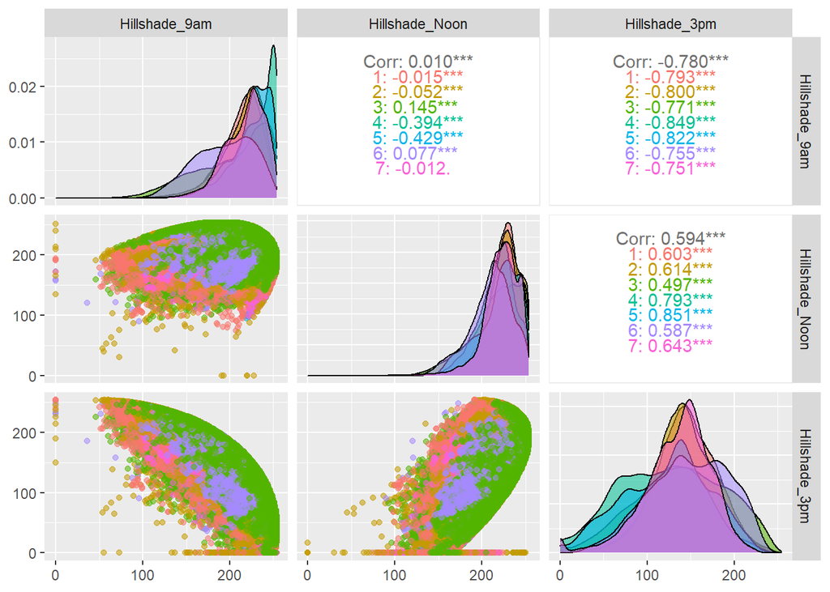

```r
ggpairs(df,
        columns = 7:9,
        aes(color = Cover_Type,
        alpha = 0.5))
```

Observing the pairplot indicates that the distributions of class labels between Hillshade_9am and Hillshade_3PM are all highly correlated thus removing Hillshade_3PM shouldn’t significantly effect predictive performance.

```r
highCors = findCorrelation(df_Cor , cutoff = .75)
df = df[,-highCors]
```

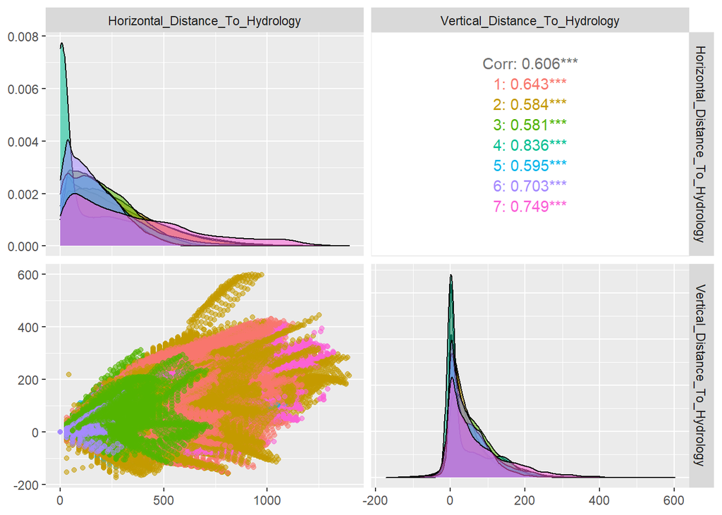

```r
### feature creation
ggpairs(df,
        columns = c(4:5),
        aes(color = Cover_Type,
        alpha = 0.5))
```

Observing the pairplot correlations indicates that there is a moderate to strong relationship between many of the class labels. When combined with variables importances observed during baseline modeling, these two features are a strong candidate fro feature creation.

```r
df$distance_to_hydrology_euclidean = (df$Horizontal_Distance_To_Hydrology^2 + df$Vertical_Distance_To_Hydrology^2)^(1/2)
df$distance_to_hydrology_manhattan = (abs(df$Horizontal_Distance_To_Hydrology) + abs(df$Vertical_Distance_To_Hydrology))
```

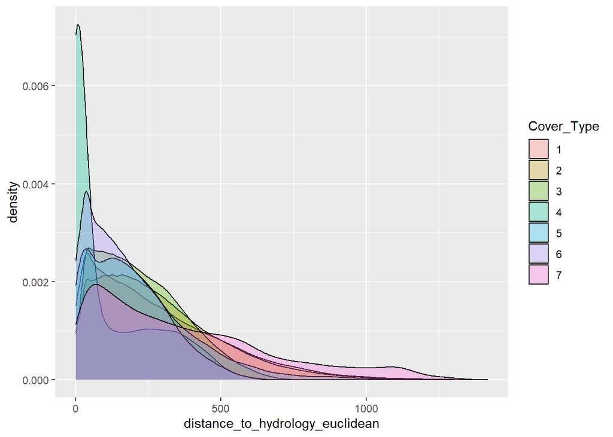

```r
ggplot(data = df, mapping = aes(x = distance_to_hydrology_euclidean, fill = Cover_Type)) + geom_density(alpha=0.3)
```

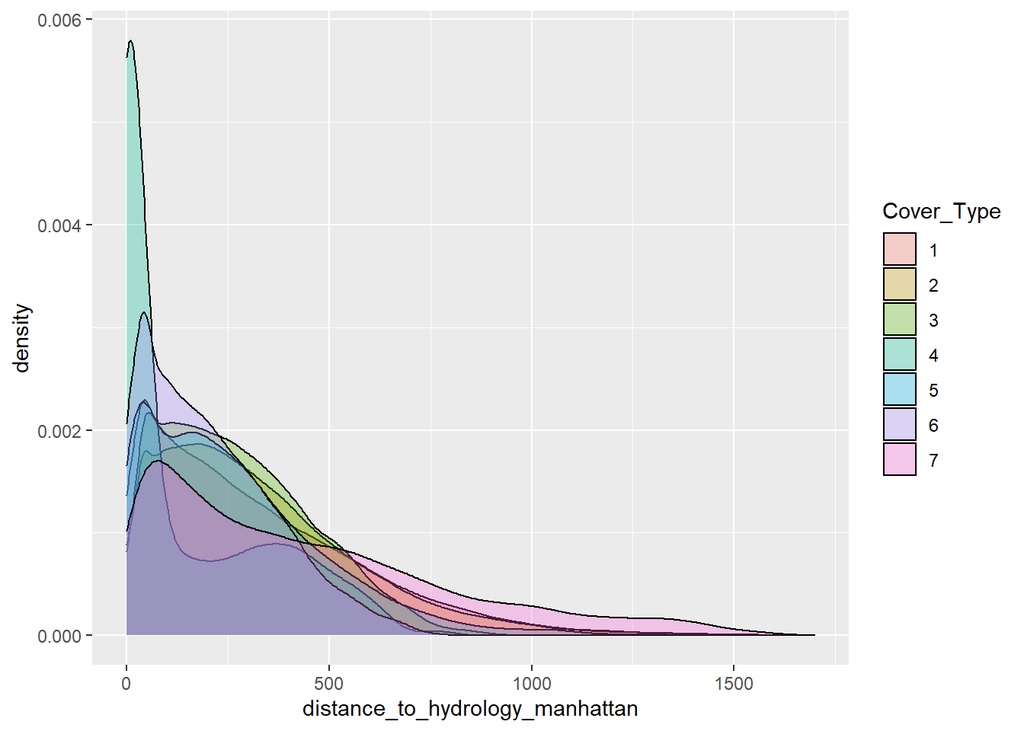

```r
ggplot(data = df, mapping = aes(x = distance_to_hydrology_manhattan, fill = Cover_Type)) + geom_density(alpha=0.3)
```

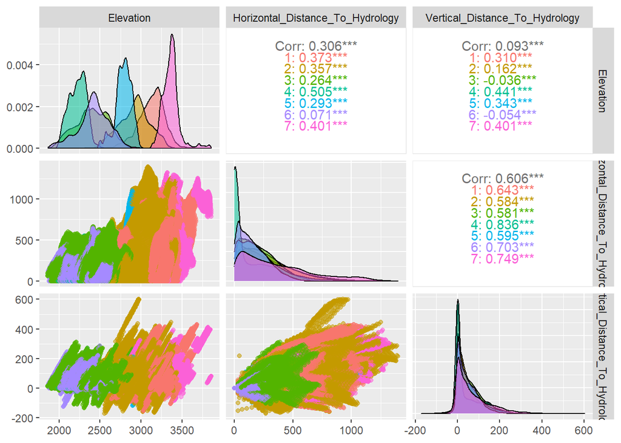

```r
### feature creation
ggpairs(df,
        columns = c(1,4:5),
        aes(color = Cover_Type,
        alpha = 0.5))
```

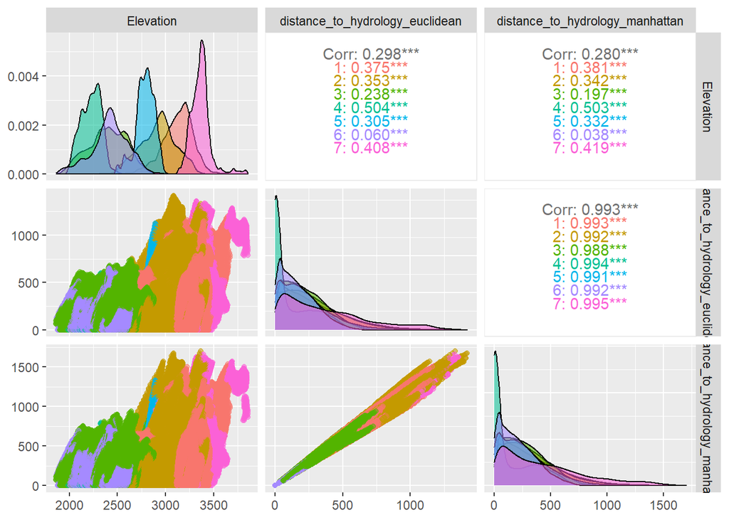

```r
ggpairs(df,
        columns = c(1,23:24),
        aes(color = Cover_Type,
        alpha = 0.5))
```

Functionally speaking, the distributions produced by calculating the euclidean and Manhattan distance are similar. For the purposes of this analysis, euclidean distance will be implmented since it creates slightly more consistent separation between classes.

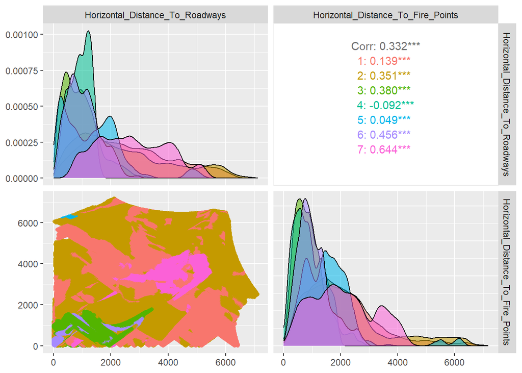

```r
ggpairs(df,
        columns = c(6,9),
        aes(color = Cover_Type,
        alpha = 0.5))
```

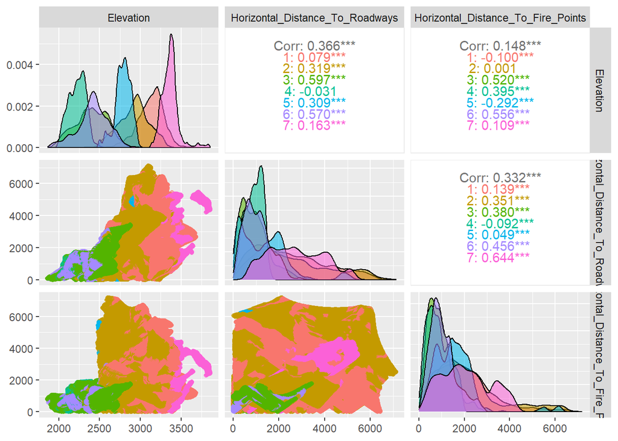

```r
ggpairs(df,
        columns = c(1,6,9),
        aes(color = Cover_Type,
        alpha = 0.5))
```

```r
df$distance_to_disturbance_min = pmin(df$Horizontal_Distance_To_Roadways, df$Horizontal_Distance_To_Fire_Points)
df$distance_to_disturbance_avg = rowMeans(df[,c(6,9)])
df$distance_to_disturbance_max = pmax(df$Horizontal_Distance_To_Roadways, df$Horizontal_Distance_To_Fire_Points)
```

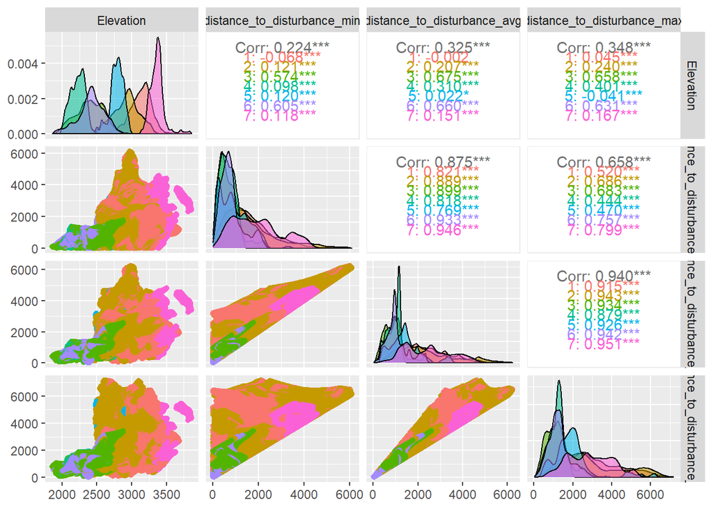

```r
ggpairs(df,
        columns = c(1,25:27),
        aes(color = Cover_Type,
        alpha = 0.5))
```

Based on the pairplots and individual distributions of our created feature, the addition of any features based on Horizontal_Distance_To_Roadways and Horizontal_Distance_To_Fire_Points does not appear to be constructive enough to implement.

```r
df = df[,-c(4,5,24:27)]
```

```r
write.csv(df,"data/covertype_preprocessed.csv", row.names = FALSE)
```